# Latella_Project_4

github link: https://github.com/ral10001/RyanAIML/upload/master/Model_Selection_and_Tuning

## Project Problem Statement - FMST

### Problem Statement: Concrete Strength Prediction

### Objective

To predict the concrete strength using the data available in file "concrete.csv". Apply feature engineering and model tuning to obtain a score above 85%.

### Resources Available

The data for this project is available in file https://archive.ics.uci.edu/ml/machine-learning-databases/concrete/compressive/. The same has been shared along with the course content.

#### Steps and Tasks:

Exploratory Data Quality Report Reflecting the Following:

- Univariate analysis –data types and description of the independent attributes which should include (name, range of values observed, central values (mean and median), standard deviation and quartiles, analysis of the body of distributions/tails, missing values, outliers, duplicates(10 Marks)
- Bi-variate analysis between the predictor variables and between the predictor variables and target column. Comment on your findings in terms of their relationship and degree of relation if any. Visualize the analysis using boxplots and pair plots, histograms, or density curves. (10 marks)
- Feature Engineering techniques(10 marks)
  1. Identify opportunities (if any) to extract new features from existing features, drop a feature(if required) Hint: Feature Extraction, for example, consider a dataset with two features length and breadth. From this, we can extract a new feature Area which would be length * breadth.
  2. Get the data model ready and do a train test split.
  3. Decide on the complexity of the model, should it be a simple linear model in terms of parameters or would a quadratic or higher degree.

#### Creating the Model and Tuning It:

- Algorithms that you think will be suitable for this project. Use Kfold Cross-Validation to evaluate model performance. Use appropriate metrics and make a DataFrame to compare models w.r.t their metrics. (at least 3 algorithms, one bagging and one boosting based algorithms have to be there). (15 marks)
- Techniques employed to squeeze that extra performance out of the model without making it overfit. Use Grid Search or Random Search on any of the two models used above. Make a DataFrame to compare models after hyperparameter tuning and their metrics as above. (15 marks)

Features

1. **Cement (cement):** kg in a m3 mixture.
2. **Blast Furnace Slag (slag):** kg in a m3 mixture.
3. **Fly Ash (ash):** kg in a m3 mixture.
4. **Water(water):** kg in a m3 mixture.
5. **Superplasticizer (superplastic):** kg in a m3 mixture.
6. **Coarse Aggregate (coarseagg):** kg in a m3 mixture.
7. **Fine Aggregate (fineagg):** kg in a m3 mixture.
8. **Age(age):** Measured in days (1~365).
9. **Concrete compressive strength(strength):** MPa (target variable)

#### Import libraries and create dataframe

```python
import pandas as pd
import numpy as np
import seaborn as sns
import matplotlib.pyplot as plt

df = pd.read_csv('concrete.csv')

%matplotlib inline
```

Viewing the shape of the dataframe

```python
df.shape
```

```
(1030, 9)
```

Checking for non-numeric datatypes

```python
df.dtypes
```

```
cement          float64
slag            float64
ash             float64
water           float64
superplastic    float64
coarseagg       float64
fineagg         float64
age               int64
strength        float64
dtype: object
```

reviewing statistical description of each column

```python
df.describe().T
```

|  | count | mean | std | min | 25% | 50% | 75% | max |
| --- | --- | --- | --- | --- | --- | --- | --- | --- |
| cement | 1030.0 | 281.167864 | 104.506364 | 102.00 | 192.375 | 272.900 | 350.000 | 540.0 |
| slag | 1030.0 | 73.895825 | 86.279342 | 0.00 | 0.000 | 22.000 | 142.950 | 359.4 |
| ash | 1030.0 | 54.188350 | 63.997004 | 0.00 | 0.000 | 0.000 | 118.300 | 200.1 |
| water | 1030.0 | 181.567282 | 21.354219 | 121.80 | 164.900 | 185.000 | 192.000 | 247.0 |
| superplastic | 1030.0 | 6.204660 | 5.973841 | 0.00 | 0.000 | 6.400 | 10.200 | 32.2 |
| coarseagg | 1030.0 | 972.918932 | 77.753954 | 801.00 | 932.000 | 968.000 | 1029.400 | 1145.0 |
| fineagg | 1030.0 | 773.580485 | 80.175980 | 594.00 | 730.950 | 779.500 | 824.000 | 992.6 |
| age | 1030.0 | 45.662136 | 63.169912 | 1.00 | 7.000 | 28.000 | 56.000 | 365.0 |
| strength | 1030.0 | 35.817961 | 16.705742 | 2.33 | 23.710 | 34.445 | 46.135 | 82.6 |

- at first glance, slag and ash may have a right skewness. Let's explore further with univariate analysis.

#### Univariate Analysis

creating histograms for slag and ash

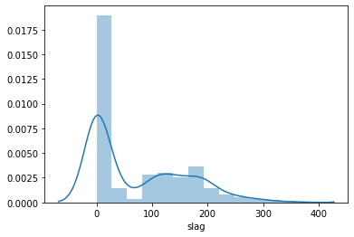

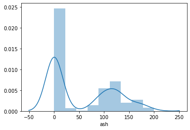

```python
for i in ['slag', 'ash']:
    sns.distplot(df[i])
    plt.show()
```

- a further look at 'slag' and 'ash' show two peaks in the distribution of the data

Also, let's take a quick look at the distribution of our target variable 'cement'

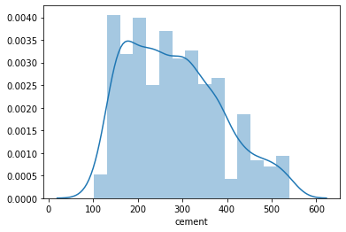

```python
sns.distplot(df.cement)
plt.show()
```

#### Missing Values

checking all columns for null values

```python
df.isnull().sum()
```

```
cement          0
slag            0
ash             0
water           0
superplastic    0
coarseagg       0
fineagg         0
age             0
strength        0
dtype: int64
```

- it does not appear that nulls exist in the data

Next, we will look for outliers and duplicates

```python
df.duplicated().sum()
```

```
25
```

- it appears we do have some duplicate values. Let's view them.

```python
# showing all duplicate rows
df[df.duplicated()]
```

|  | cement | slag | ash | water | superplastic | coarseagg | fineagg | age | strength |
| --- | --- | --- | --- | --- | --- | --- | --- | --- | --- |
| 278 | 425.0 | 106.3 | 0.0 | 153.5 | 16.5 | 852.1 | 887.1 | 3 | 33.40 |
| 298 | 425.0 | 106.3 | 0.0 | 153.5 | 16.5 | 852.1 | 887.1 | 3 | 33.40 |
| 400 | 362.6 | 189.0 | 0.0 | 164.9 | 11.6 | 944.7 | 755.8 | 3 | 35.30 |
| 420 | 362.6 | 189.0 | 0.0 | 164.9 | 11.6 | 944.7 | 755.8 | 3 | 35.30 |
| 463 | 362.6 | 189.0 | 0.0 | 164.9 | 11.6 | 944.7 | 755.8 | 56 | 77.30 |
| 468 | 252.0 | 0.0 | 0.0 | 185.0 | 0.0 | 1111.0 | 784.0 | 28 | 19.69 |
| 482 | 425.0 | 106.3 | 0.0 | 153.5 | 16.5 | 852.1 | 887.1 | 91 | 65.20 |
| 493 | 362.6 | 189.0 | 0.0 | 164.9 | 11.6 | 944.7 | 755.8 | 91 | 79.30 |
| 517 | 425.0 | 106.3 | 0.0 | 153.5 | 16.5 | 852.1 | 887.1 | 56 | 64.30 |
| 525 | 362.6 | 189.0 | 0.0 | 164.9 | 11.6 | 944.7 | 755.8 | 28 | 71.30 |
| 527 | 425.0 | 106.3 | 0.0 | 153.5 | 16.5 | 852.1 | 887.1 | 91 | 65.20 |
| 576 | 362.6 | 189.0 | 0.0 | 164.9 | 11.6 | 944.7 | 755.8 | 7 | 55.90 |
| 577 | 425.0 | 106.3 | 0.0 | 153.5 | 16.5 | 852.1 | 887.1 | 28 | 60.29 |
| 604 | 362.6 | 189.0 | 0.0 | 164.9 | 11.6 | 944.7 | 755.8 | 56 | 77.30 |
| 733 | 362.6 | 189.0 | 0.0 | 164.9 | 11.6 | 944.7 | 755.8 | 91 | 79.30 |
| 738 | 362.6 | 189.0 | 0.0 | 164.9 | 11.6 | 944.7 | 755.8 | 28 | 71.30 |
| 766 | 362.6 | 189.0 | 0.0 | 164.9 | 11.6 | 944.7 | 755.8 | 91 | 79.30 |
| 830 | 425.0 | 106.3 | 0.0 | 153.5 | 16.5 | 852.1 | 887.1 | 7 | 49.20 |
| 880 | 425.0 | 106.3 | 0.0 | 153.5 | 16.5 | 852.1 | 887.1 | 56 | 64.30 |
| 884 | 425.0 | 106.3 | 0.0 | 153.5 | 16.5 | 852.1 | 887.1 | 7 | 49.20 |
| 892 | 362.6 | 189.0 | 0.0 | 164.9 | 11.6 | 944.7 | 755.8 | 56 | 77.30 |
| 933 | 362.6 | 189.0 | 0.0 | 164.9 | 11.6 | 944.7 | 755.8 | 7 | 55.90 |
| 943 | 362.6 | 189.0 | 0.0 | 164.9 | 11.6 | 944.7 | 755.8 | 3 | 35.30 |
| 967 | 362.6 | 189.0 | 0.0 | 164.9 | 11.6 | 944.7 | 755.8 | 28 | 71.30 |
| 992 | 425.0 | 106.3 | 0.0 | 153.5 | 16.5 | 852.1 | 887.1 | 28 | 60.29 |

above we can see the duplicate rows. Let's remove all duplicates next.

```python
df.drop_duplicates(inplace=True)
print(df.shape)
```

```
(1005, 9)
```

Let's look at the distribution of features

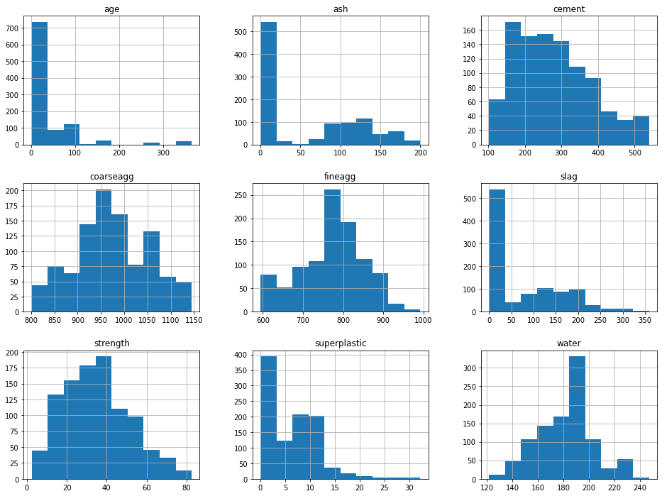

```python
df.hist(figsize=(16,12))
plt.show()
```

- age, ash, and slag seem to have large spike in the low value range. Let's dive deeper into these fields to identify outliers

Next, we will look for potential outliers utilizing bloxplots

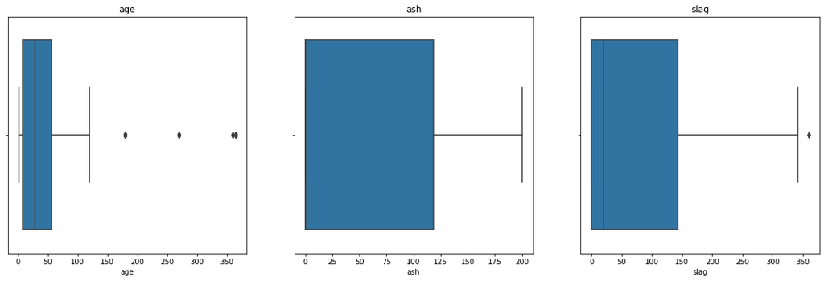

```python
feats = ['age', 'ash', 'slag']
fig, ax = plt.subplots(1,3, figsize=(20, 6))
n = 0
for f in feats:
    sns.boxplot(df[f], ax=ax[n])
    ax[n].set_title(f)
    n += 1
plt.show()
```

- 'age' has several outliers worth looking into further.

```python
df[df.age > 250]
```

|  | cement | slag | ash | water | superplastic | coarseagg | fineagg | age | strength |
| --- | --- | --- | --- | --- | --- | --- | --- | --- | --- |
| 64 | 332.5 | 142.5 | 0.0 | 228.0 | 0.0 | 932.0 | 594.0 | 365 | 41.05 |
| 133 | 236.0 | 0.0 | 0.0 | 193.0 | 0.0 | 968.0 | 885.0 | 365 | 25.08 |
| 149 | 380.0 | 95.0 | 0.0 | 228.0 | 0.0 | 932.0 | 594.0 | 270 | 41.15 |
| 157 | 198.6 | 132.4 | 0.0 | 192.0 | 0.0 | 978.4 | 825.5 | 360 | 44.30 |
| 159 | 304.0 | 76.0 | 0.0 | 228.0 | 0.0 | 932.0 | 670.0 | 365 | 55.26 |
| 198 | 266.0 | 114.0 | 0.0 | 228.0 | 0.0 | 932.0 | 670.0 | 365 | 52.91 |
| 256 | 525.0 | 0.0 | 0.0 | 189.0 | 0.0 | 1125.0 | 613.0 | 270 | 67.11 |
| 262 | 266.0 | 114.0 | 0.0 | 228.0 | 0.0 | 932.0 | 670.0 | 270 | 51.73 |
| 270 | 500.0 | 0.0 | 0.0 | 200.0 | 0.0 | 1125.0 | 613.0 | 270 | 55.16 |
| 297 | 475.0 | 0.0 | 0.0 | 228.0 | 0.0 | 932.0 | 594.0 | 270 | 42.13 |
| 313 | 540.0 | 0.0 | 0.0 | 173.0 | 0.0 | 1125.0 | 613.0 | 270 | 74.17 |
| 323 | 139.6 | 209.4 | 0.0 | 192.0 | 0.0 | 1047.0 | 806.9 | 360 | 44.70 |
| 361 | 277.0 | 0.0 | 0.0 | 191.0 | 0.0 | 968.0 | 856.0 | 360 | 33.70 |
| 393 | 342.0 | 38.0 | 0.0 | 228.0 | 0.0 | 932.0 | 670.0 | 365 | 56.14 |
| 448 | 331.0 | 0.0 | 0.0 | 192.0 | 0.0 | 978.0 | 825.0 | 360 | 41.24 |
| 465 | 427.5 | 47.5 | 0.0 | 228.0 | 0.0 | 932.0 | 594.0 | 365 | 43.70 |
| 484 | 237.5 | 237.5 | 0.0 | 228.0 | 0.0 | 932.0 | 594.0 | 365 | 39.00 |
| 570 | 190.0 | 190.0 | 0.0 | 228.0 | 0.0 | 932.0 | 670.0 | 270 | 50.66 |
| 601 | 339.0 | 0.0 | 0.0 | 197.0 | 0.0 | 968.0 | 781.0 | 365 | 38.89 |
| 623 | 380.0 | 0.0 | 0.0 | 228.0 | 0.0 | 932.0 | 670.0 | 270 | 53.30 |
| 632 | 304.0 | 76.0 | 0.0 | 228.0 | 0.0 | 932.0 | 670.0 | 270 | 54.38 |
| 713 | 190.0 | 190.0 | 0.0 | 228.0 | 0.0 | 932.0 | 670.0 | 365 | 53.69 |
| 720 | 380.0 | 95.0 | 0.0 | 228.0 | 0.0 | 932.0 | 594.0 | 365 | 43.70 |
| 754 | 254.0 | 0.0 | 0.0 | 198.0 | 0.0 | 968.0 | 863.0 | 365 | 29.79 |
| 755 | 349.0 | 0.0 | 0.0 | 192.0 | 0.0 | 1047.0 | 806.0 | 360 | 42.13 |
| 850 | 427.5 | 47.5 | 0.0 | 228.0 | 0.0 | 932.0 | 594.0 | 270 | 43.01 |
| 878 | 237.5 | 237.5 | 0.0 | 228.0 | 0.0 | 932.0 | 594.0 | 270 | 38.41 |
| 901 | 475.0 | 0.0 | 0.0 | 228.0 | 0.0 | 932.0 | 594.0 | 365 | 41.93 |
| 919 | 310.0 | 0.0 | 0.0 | 192.0 | 0.0 | 970.0 | 850.0 | 360 | 38.11 |
| 951 | 332.5 | 142.5 | 0.0 | 228.0 | 0.0 | 932.0 | 594.0 | 270 | 40.27 |
| 957 | 307.0 | 0.0 | 0.0 | 193.0 | 0.0 | 968.0 | 812.0 | 365 | 36.15 |
| 995 | 380.0 | 0.0 | 0.0 | 228.0 | 0.0 | 932.0 | 670.0 | 365 | 52.52 |
| 1028 | 342.0 | 38.0 | 0.0 | 228.0 | 0.0 | 932.0 | 670.0 | 270 | 55.06 |

Describing the subset of outliers and comparing to full dataset

```python
df[df.age > 250].describe()
```

|  | cement | slag | ash | water | superplastic | coarseagg | fineagg | age | strength |
| --- | --- | --- | --- | --- | --- | --- | --- | --- | --- |
| count | 33.000000 | 33.000000 | 33.0 | 33.000000 | 33.0 | 33.000000 | 33.000000 | 33.000000 | 33.000000 |
| mean | 332.581818 | 67.357576 | 0.0 | 213.757576 | 0.0 | 965.921212 | 690.587879 | 326.666667 | 46.076667 |
| std | 100.052431 | 79.111314 | 0.0 | 18.367822 | 0.0 | 59.271240 | 100.299155 | 46.429831 | 10.098376 |
| min | 139.600000 | 0.000000 | 0.0 | 173.000000 | 0.0 | 932.000000 | 594.000000 | 270.000000 | 25.080000 |
| 25% | 266.000000 | 0.000000 | 0.0 | 193.000000 | 0.0 | 932.000000 | 594.000000 | 270.000000 | 40.270000 |
| 50% | 332.500000 | 38.000000 | 0.0 | 228.000000 | 0.0 | 932.000000 | 670.000000 | 360.000000 | 43.700000 |
| 75% | 380.000000 | 114.000000 | 0.0 | 228.000000 | 0.0 | 968.000000 | 806.000000 | 365.000000 | 53.300000 |
| max | 540.000000 | 237.500000 | 0.0 | 228.000000 | 0.0 | 1125.000000 | 885.000000 | 365.000000 | 74.170000 |

```python
df.describe()
```

|  | cement | slag | ash | water | superplastic | coarseagg | fineagg | age | strength |
| --- | --- | --- | --- | --- | --- | --- | --- | --- | --- |
| count | 1005.000000 | 1005.000000 | 1005.000000 | 1005.000000 | 1005.000000 | 1005.000000 | 1005.000000 | 1005.000000 | 1005.000000 |
| mean | 278.631343 | 72.043483 | 55.536318 | 182.075323 | 6.033234 | 974.376816 | 772.688259 | 45.856716 | 35.250378 |
| std | 104.344261 | 86.170807 | 64.207969 | 21.339334 | 5.919967 | 77.579667 | 80.340435 | 63.734692 | 16.284815 |
| min | 102.000000 | 0.000000 | 0.000000 | 121.800000 | 0.000000 | 801.000000 | 594.000000 | 1.000000 | 2.330000 |
| 25% | 190.700000 | 0.000000 | 0.000000 | 166.600000 | 0.000000 | 932.000000 | 724.300000 | 7.000000 | 23.520000 |
| 50% | 265.000000 | 20.000000 | 0.000000 | 185.700000 | 6.100000 | 968.000000 | 780.000000 | 28.000000 | 33.800000 |
| 75% | 349.000000 | 142.500000 | 118.300000 | 192.900000 | 10.000000 | 1031.000000 | 822.200000 | 56.000000 | 44.870000 |
| max | 540.000000 | 359.400000 | 200.100000 | 247.000000 | 32.200000 | 1145.000000 | 992.600000 | 365.000000 | 82.600000 |

- I feel comfortable keeping all data points. There are no major issues in my eyes with the descriptive statistics of the outliers versus the entire dataset

#### Bivariate Analysis

Next we will look at scatterplots of all features and correlation values. High correlation may signify multicollinearity

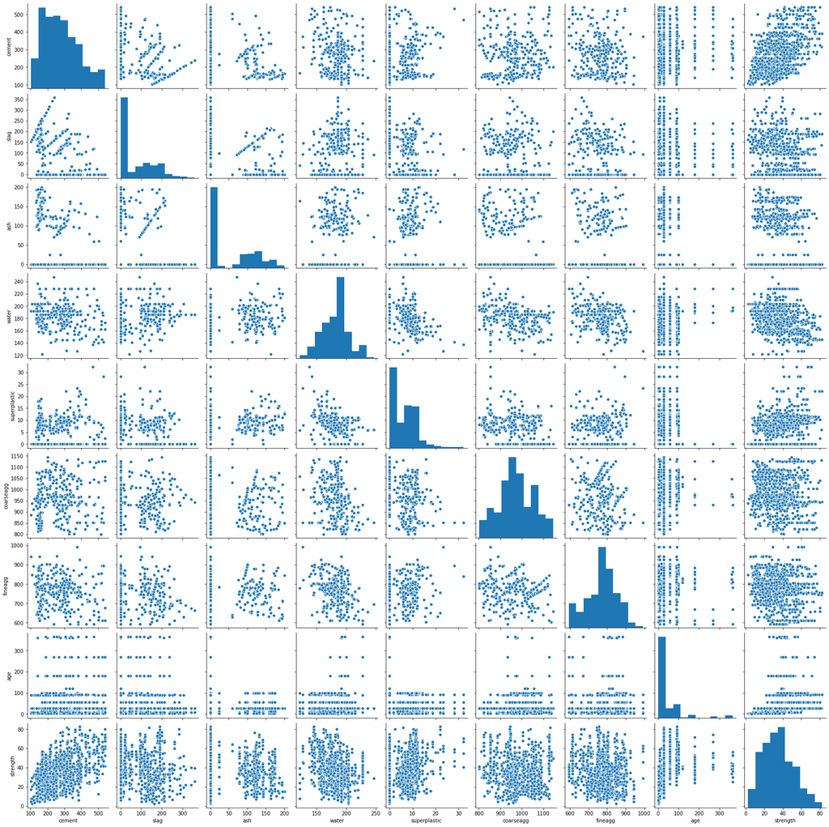

```python
sns.pairplot(df)
plt.show()
```

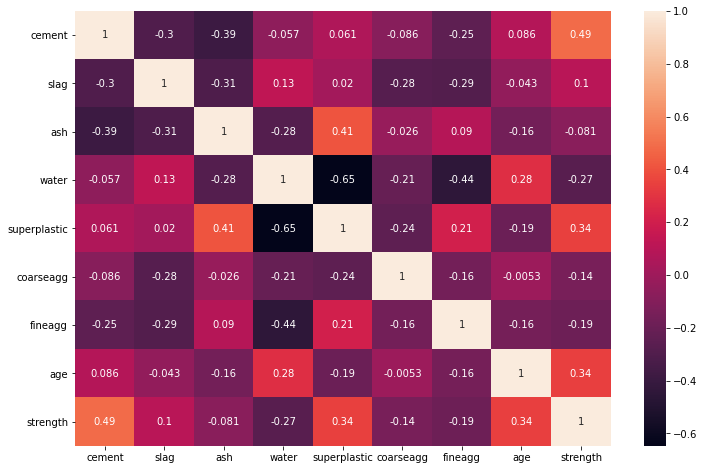

```python
corr = df.corr()
fig = plt.figure(figsize=(12, 8))
sns.heatmap(corr, annot=True)
plt.show()
```

Bivariate findings -

- cement and strength have the highest positive correlation of 0.49, while cement has the lowest negative correlation with ash of -0.39
- water and superplastic have a decent negative correlation at -0.65

#### Feature Engineering

I am creating a coarse aggregate to fine aggregate ratio to see if this has any predictive strength when determining cement value

```python
df['cf_ratio'] = round(df['coarseagg']/df['fineagg'], 2)
```

```python
df
```

|  | cement | slag | ash | water | superplastic | coarseagg | fineagg | age | strength | cf_ratio |
| --- | --- | --- | --- | --- | --- | --- | --- | --- | --- | --- |
| 0 | 141.3 | 212.0 | 0.0 | 203.5 | 0.0 | 971.8 | 748.5 | 28 | 29.89 | 1.30 |
| 1 | 168.9 | 42.2 | 124.3 | 158.3 | 10.8 | 1080.8 | 796.2 | 14 | 23.51 | 1.36 |
| 2 | 250.0 | 0.0 | 95.7 | 187.4 | 5.5 | 956.9 | 861.2 | 28 | 29.22 | 1.11 |
| 3 | 266.0 | 114.0 | 0.0 | 228.0 | 0.0 | 932.0 | 670.0 | 28 | 45.85 | 1.39 |
| 4 | 154.8 | 183.4 | 0.0 | 193.3 | 9.1 | 1047.4 | 696.7 | 28 | 18.29 | 1.50 |
| ... | ... | ... | ... | ... | ... | ... | ... | ... | ... | ... |
| 1025 | 135.0 | 0.0 | 166.0 | 180.0 | 10.0 | 961.0 | 805.0 | 28 | 13.29 | 1.19 |
| 1026 | 531.3 | 0.0 | 0.0 | 141.8 | 28.2 | 852.1 | 893.7 | 3 | 41.30 | 0.95 |
| 1027 | 276.4 | 116.0 | 90.3 | 179.6 | 8.9 | 870.1 | 768.3 | 28 | 44.28 | 1.13 |
| 1028 | 342.0 | 38.0 | 0.0 | 228.0 | 0.0 | 932.0 | 670.0 | 270 | 55.06 | 1.39 |
| 1029 | 540.0 | 0.0 | 0.0 | 173.0 | 0.0 | 1125.0 | 613.0 | 7 | 52.61 | 1.84 |

1005 rows × 10 columns

Let's split the data into training and testing sets

```python
from sklearn.model_selection import train_test_split

X = df.iloc[:, 1:]
y = df.cement

X_train, X_test, y_train, y_test = train_test_split(X, y, test_size=0.25, random_state=14)
```

Let us also create training and testing sets of scaled polynomial features to see if there is any impact when modeling

```python
from sklearn.preprocessing import PolynomialFeatures, StandardScaler

# create X and y for poly features
X_prep = df.iloc[:, 1:]
yp = df.cement

# scale X
ss = StandardScaler()
X_scaled = ss.fit_transform(X_prep)
X_scaled = pd.DataFrame(X_scaled, columns=X_prep.columns)

# create poly features to the 2nd degree
pf = PolynomialFeatures(2)
X_poly = pd.DataFrame(pf.fit_transform(X_scaled), columns=pf.get_feature_names(X_scaled.columns))
X_poly.drop('1', axis=1, inplace=True)

# splitting the polynomial features into training and testing data sets
Xp_train, Xp_test, yp_train, yp_test = train_test_split(X_poly, yp, test_size=0.25, random_state=14)
```

#### Feature Selection

Let's check to see if all features will be impactful

```python
from mlxtend.feature_selection import SequentialFeatureSelector as sfs
from sklearn.ensemble import RandomForestRegressor
```

```python
rftest = RandomForestRegressor()
```

```python
sfs1 = sfs(rftest, k_features='best', forward=True, scoring='r2', cv=5).fit(X_train, y_train)
```

```python
from mlxtend.plotting import plot_sequential_feature_selection as plot_sfs
import matplotlib.pyplot as plt
```

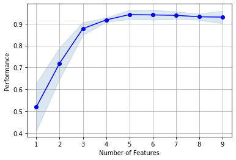

```python
fig = plot_sfs(sfs1.get_metric_dict())
plt.grid()
plt.show()
```

- the model performance seems to level out around 5 or 6 features with a slight decrease when adding more features.

pull the best features

```python
pd.DataFrame({'Best Features': sfs1.k_feature_names_})
```

|  | Best Features |
| --- | --- |
| 0 | slag |
| 1 | ash |
| 2 | water |
| 3 | coarseagg |
| 4 | fineagg |

```python
X_new_train, X_new_test, y_new_train, y_new_test = train_test_split(X.loc[:,list(sfs1.k_feature_names_)], y, random_state=14, test_size=.25)
```

### Create the model

#### Random forest

run random forest on the first train and test datasets (non-polynomial)

```python
y_train = y_train.astype(int)
y_test = y_test.astype(int)
```

```python
from sklearn.ensemble import RandomForestRegressor
from sklearn.metrics import mean_squared_error
rf = RandomForestRegressor(criterion='mse', random_state=14)
```

```python
rf.fit(X_train, y_train)
rf_pred = rf.predict(X_test)
```

```python
rf_train_r2 = rf.score(X_train, y_train)
rf_test_r2 = rf.score(X_test, y_test)
rf_mse = mean_squared_error(y_test, rf_pred)
rf_rmse = np.sqrt(rf_mse)


rf_scores = [rf_train_r2, rf_test_r2, rf_mse, rf_rmse]
rf_mets = ['Train r squared', 'Test r squared', 'MSE', 'RMSE']

rf_metrics_df = pd.DataFrame({'Metrics': rf_mets, 'Scores': rf_scores})
rf_metrics_df
```

|  | Metrics | Scores |
| --- | --- | --- |
| 0 | Train r squared | 0.991138 |
| 1 | Test r squared | 0.964723 |
| 2 | MSE | 376.601051 |
| 3 | RMSE | 19.406212 |

- looking at the train and test r squared values, the model performs very well, only dropping .03 from 0.99 to 0.96 for the train and test score respectively
- The RMSE is a bit high at 19. We can try boosting this model. I will try boosting this method with AdaBoostRegressor

```python
y_new_train = y_new_train.astype(int)
y_new_test = y_new_test.astype(int)
```

```python
rfn = RandomForestRegressor(criterion='mse', random_state=14)
```

```python
rfn.fit(X_new_train, y_new_train)
rfn_pred = rfn.predict(X_new_test)
```

```python
rfn_train_r2 = rfn.score(X_new_train, y_new_train)
rfn_test_r2 = rfn.score(X_new_test, y_test)
rfn_mse = mean_squared_error(y_new_test, rfn_pred)
rfn_rmse = np.sqrt(rfn_mse)


rfn_scores = [rfn_train_r2, rfn_test_r2, rfn_mse, rfn_rmse]
rfn_mets = ['Train r squared', 'Test r squared', 'MSE', 'RMSE']

rfn_metrics_df = pd.DataFrame({'Metrics': rfn_mets, 'Scores': rfn_scores})
rfn_metrics_df
```

|  | Metrics | Scores |
| --- | --- | --- |
| 0 | Train r squared | 0.992222 |
| 1 | Test r squared | 0.966370 |
| 2 | MSE | 359.015661 |
| 3 | RMSE | 18.947709 |

- trimming the features does not seem to make much of a difference. I will continue on with all features.

#### Adaboost Ensemble Algorithm

```python
from sklearn.ensemble import AdaBoostRegressor
ab = AdaBoostRegressor(base_estimator=rf, random_state=14)
```

```python
ab.fit(X_train, y_train)
```

```
AdaBoostRegressor(base_estimator=RandomForestRegressor(random_state=14),
                  random_state=14)
```

```python
ab_pred = ab.predict(X_test)
```

```python
ab_train_r2 = ab.score(X_train, y_train)
ab_test_r2 = ab.score(X_test, y_test)
ab_mse = mean_squared_error(y_test, ab_pred)
ab_rmse = np.sqrt(ab_mse)

ab_scores = [ab_train_r2, ab_test_r2, ab_mse, ab_rmse]
ab_mets = ['Train r squared', 'Test r squared', 'MSE', 'RMSE']

ab_metrics_df = pd.DataFrame({'Metrics': ab_mets, 'Scores': ab_scores})
ab_metrics_df
```

|  | Metrics | Scores |
| --- | --- | --- |
| 0 | Train r squared | 0.964085 |
| 1 | Test r squared | 0.938329 |
| 2 | MSE | 658.370845 |
| 3 | RMSE | 25.658738 |

- using AdaBoost with the random forest algorithm as the base_estimator, the r squared scores actually decrease while the rmse increases to 25.6 (an increase of more than 6 from the 19 seen in the random regressor algorithm)
- so far, random forest is looking the best. Running random search on random forest may return the best model results. Before trying that, I will try a bagging method on the random_forest model

```python
from sklearn.ensemble import BaggingRegressor
```

Running the bagging regressor with random forest as the base estimator

```python
br = BaggingRegressor(base_estimator=rf, random_state=14)
```

```python
br.fit(X_train, y_train)
br_pred = br.predict(X_test)
```

```python
br_train_r2 = br.score(X_train, y_train)
br_test_r2 = br.score(X_test, y_test)
br_mse = mean_squared_error(y_test, br_pred)
br_rmse = np.sqrt(br_mse)

br_scores = [br_train_r2, br_test_r2, br_mse, br_rmse]
br_mets = ['Train r squared', 'Test r squared', 'MSE', 'RMSE']

br_metrics_df = pd.DataFrame({'Metrics': br_mets, 'Scores': br_scores})
br_metrics_df
```

|  | Metrics | Scores |
| --- | --- | --- |
| 0 | Train r squared | 0.967070 |
| 1 | Test r squared | 0.938590 |
| 2 | MSE | 655.585138 |
| 3 | RMSE | 25.604397 |

- performs identically to AdaBoost with the Random Forest base estimator.

Running the bagging regressor with no specified base estimator

```python
brn = BaggingRegressor(base_estimator=None, random_state=14)
```

```python
brn.fit(X_train, y_train)
brn_pred = brn.predict(X_test)
```

```python
brn_train_r2 = brn.score(X_train, y_train)
brn_test_r2 = brn.score(X_test, y_test)
brn_mse = mean_squared_error(y_test, brn_pred)
brn_rmse = np.sqrt(brn_mse)

brn_scores = [brn_train_r2, brn_test_r2, brn_mse, brn_rmse]
brn_mets = ['Train r squared', 'Test r squared', 'MSE', 'RMSE']

brn_metrics_df = pd.DataFrame({'Metrics': brn_mets, 'Scores': brn_scores})
brn_metrics_df
```

|  | Metrics | Scores |
| --- | --- | --- |
| 0 | Train r squared | 0.981155 |
| 1 | Test r squared | 0.953816 |
| 2 | MSE | 493.032619 |
| 3 | RMSE | 22.204338 |

#### Dataframe comparing models

```python
final_scores = pd.DataFrame(columns=['Metrics', 'Random Forest', 'AdaBoost (random forest)', 'Bagging (random forest)', 'Bagging'])
all_scores = [rf_metrics_df['Metrics'], rf_metrics_df['Scores'], ab_metrics_df['Scores'], br_metrics_df['Scores'], brn_metrics_df['Scores']]
for c, s in zip(final_scores.columns, all_scores):
    final_scores[c] = s.values
```

```python
final_scores
```

|  | Metrics | Random Forest | AdaBoost (random forest) | Bagging (random forest) | Bagging |
| --- | --- | --- | --- | --- | --- |
| 0 | Train r squared | 0.991138 | 0.964085 | 0.967070 | 0.981155 |
| 1 | Test r squared | 0.964723 | 0.938329 | 0.938590 | 0.953816 |
| 2 | MSE | 376.601051 | 658.370845 | 655.585138 | 493.032619 |
| 3 | RMSE | 19.406212 | 25.658738 | 25.604397 | 22.204338 |

- at this point, we can see that random forest performs the best of these four models
- the r squared scores are quite high for random forest. This is good. I would, however, like to improve the RMSE of this model. I will first run kfold cross validation on the random forest model, and then I will use Random Search to accomplish this

#### KFold Cross Validation

```python
# Evaluate using Cross Validation
from sklearn import model_selection
import warnings

warnings.simplefilter('ignore')
```

```python
seed = 14
kfold = model_selection.KFold(n_splits=20, random_state=seed)
```

```python
results = model_selection.cross_val_score(rf, X, y, scoring='neg_mean_squared_error', cv=kfold)
print("Mean Square Error: %.3f" % (np.sqrt(-results.mean())))
```

```
Mean Square Error: 19.466
```

- even after running cross validation, the rmse hovers right around 19

#### Random Search

```python
from sklearn.model_selection import RandomizedSearchCV
from scipy.stats import randint as sp_randint
```

make a parameter dictionary for the random forest algorithm

```python
rf_params = {"max_depth": [5, None],
              "max_features": [sp_randint(1, 9), 'auto'],
              "min_samples_split": sp_randint(2, 10),
              "min_samples_leaf": sp_randint(1, 10),
              "bootstrap": [True, False],
              "n_estimators": [10, 100],
              "criterion": ['mse']}
```

run the random search based on these parameter ranges

```python
samples = 10
rand_search = RandomizedSearchCV(rf, param_distributions=rf_params, n_iter=samples, random_state=14)
```

```python
rand_search.fit(X, y)
rand_search.best_params_
```

```
{'bootstrap': True,
 'criterion': 'mse',
 'max_depth': None,
 'max_features': 'auto',
 'min_samples_leaf': 4,
 'min_samples_split': 3,
 'n_estimators': 100}
```

- use the best parameters in the random forest algorithm

```python
params = {'bootstrap': True,
     'criterion': 'mse',
     'max_depth': None,
     'max_features': 'auto',
     'min_samples_leaf': 4,
     'min_samples_split': 3,
     'n_estimators': 100}

rf_final = RandomForestRegressor(**params)
```

```python
rf_final.fit(X_train, y_train)
rf_final_pred = rf_final.predict(X_test)
```

```python
rf_final_train_r2 = rf_final.score(X_train, y_train)
rf_final_test_r2 = rf_final.score(X_test, y_test)
rf_final_mse = mean_squared_error(y_test, rf_final_pred)
rf_final_rmse = np.sqrt(rf_final_mse)


rf_final_scores = [rf_final_train_r2, rf_final_test_r2, rf_final_mse, rf_final_rmse]
rf_final_mets = ['Train r squared', 'Test r squared', 'MSE', 'RMSE']

rf_final_metrics_df = pd.DataFrame({'Metrics': rf_final_mets, 'Scores': rf_final_scores})
rf_final_metrics_df
```

|  | Metrics | Scores |
| --- | --- | --- |
| 0 | Train r squared | 0.968312 |
| 1 | Test r squared | 0.939799 |
| 2 | MSE | 642.677621 |
| 3 | RMSE | 25.351087 |

- Although this model is still performing well, it is not quite as good as the initial random forest model. If I had to go with one model, it would be my first random forest model (rf)

final metrics dataframe

```python
final_mets = pd.DataFrame(columns=['Metrics', 'Random Forest', 'AdaBoost (random forest)', 'Bagging (random forest)', 'Bagging', \
                                   'Random Search (rf)'])
all_mets = [rf_metrics_df['Metrics'], rf_metrics_df['Scores'], ab_metrics_df['Scores'], br_metrics_df['Scores'], \
            brn_metrics_df['Scores'], rf_final_metrics_df['Scores']]
for c, s in zip(final_mets.columns, all_mets):
    final_mets[c] = s.values
```

```python
final_mets
```

|  | Metrics | Random Forest | AdaBoost (random forest) | Bagging (random forest) | Bagging | Random Search (rf) |
| --- | --- | --- | --- | --- | --- | --- |
| 0 | Train r squared | 0.991138 | 0.964085 | 0.967070 | 0.981155 | 0.968312 |
| 1 | Test r squared | 0.964723 | 0.938329 | 0.938590 | 0.953816 | 0.939799 |
| 2 | MSE | 376.601051 | 658.370845 | 655.585138 | 493.032619 | 642.677621 |
| 3 | RMSE | 19.406212 | 25.658738 | 25.604397 | 22.204338 | 25.351087 |